```r
require(BSDA)
library(BSDA)
require(EnvStats)
library(EnvStats)
```

```r
n <- 13
k <- 100
l <- 50
set.seed(13)
```

## Data generating

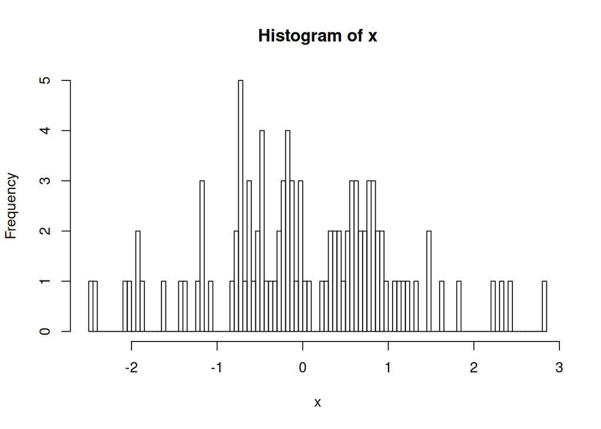

```r
a_k <- c()
for(i in 1:k) {
  a_k <- append(a_k, i * log(i^2*n + pi) - floor(i * log(i^2*n + pi)))
}

a_l <- c()
for(i in 1:(l + 100)) {
  a_l <- append(a_l, i * log(i^2*n + pi) - floor(i * log(i^2*n + pi)))
}
x <- qnorm(a_k)
y <- qnorm(a_l)

h_x <- hist(x, breaks = 100, plot = FALSE)
cuts <- cut(h_x$breaks, c(-Inf, -.005, Inf))
plot(h_x)
```

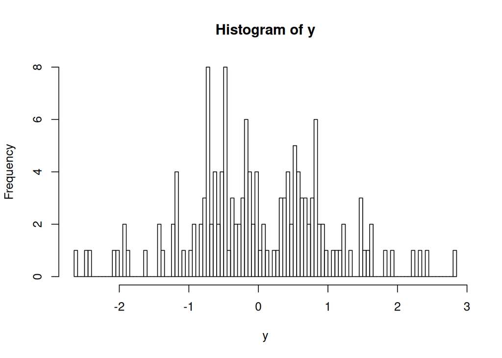

```r
h_y <- hist(y, breaks = 150, plot = FALSE)
cuts <- cut(h_y$breaks, c(-Inf, -.005, Inf))
plot(h_y)
```

### Problem 1

$$H_{0}: \mu_{1}^2 = \mu_{2}^2 \ \ vs\ H_{1}:\mu_{1}\ !=\ \mu_{2};
\\\sigma_{1}^2 = \sigma_{2}^2 = 1;$$
Here we use two-sided $z$-test, because we know $\sigma$ of distributions, and we need to test $\mu$ of two distributions and alternative hypothesis is arbitrary (!=).

In Generalized Likelihood Ratio Test he reject $H_{0}$ at size $\alpha$ (0.05 in your case), when:
$$2logL_{x}(H_{0},H_{1}) ≥ \chi^{(m)}_{1-\alpha}$$

For two-sided $z$-test we can use:
$$|z(x, y)| ≥ z_{0.975}$$

$p$-value of the test is the smallest $\alpha$ at which $H_{0}$ can be rejected.

If it is small enough, we reject $H_{0}$, otherwise, we do not reject it.

For two-sided $z$-test:
$$p(x,y)=2\phi(-|z(x,y|)$$

In our case p ≈ 0.85, it is quite big value, so we do not reject $H_{0}$.

If we check sample means, we really see that they are approximately equal.

```r
alpha = .05
z.test(x=x, y=y, alternative="two.sided", sigma.x=1, sigma.y=1, conf.level=1-alpha)
```

```
##
##  Two-sample z-Test
##
## data:  x and y
## z = 0.19502, p-value = 0.8454
## alternative hypothesis: true difference in means is not equal to 0
## 95 percent confidence interval:
##  -0.2278537  0.2782068
## sample estimates:
##    mean of x    mean of y
##  0.019826552 -0.005349991
```

### Problem 2

$$H_{0}: \sigma_{1}^2 = \sigma_{2}^2 \ \ vs \ \ H_{1}: \sigma_{1}^2 > \sigma_{2}^2;$$

$\mu1$ and $\mu2$ are unknown

Here we use one-sided $f$-test, because we have unknown $\mu$ and $\sigma$ of distributions,

and we need to test $\sigma$ of two distributions and alternative hypothesis bigger (>).

and reject $H_{0}$ otherwise.

For this test $p$-value is equal to:

```r
alpha = .05
var.test(x=x, y=y, alternative = "g", con.level = 1 - alpha)
```

```
##
##  F test to compare two variances
##
## data:  x and y
## F = 1.1036, num df = 99, denom df = 149, p-value = 0.2909
## alternative hypothesis: true ratio of variances is greater than 1
## 95 percent confidence interval:
##  0.8196242       Inf
## sample estimates:
## ratio of variances
##           1.103628
```

### Problem 3

Kolmogorov-Smirnov test is used to test if two samples have the same distributions.

In first and second tests we compare distribution of $F_{x}$, which is unknown,

with normal and exponensial distributions respectively.

In the third test we compare unknown distributions $F_{x}$ and $F_{y}$, to check if they are similar.

D is maximal vertical distance between ECDF and CDF, so the lower it is, the smaller is difference between practical and theoretical value.

$p$-value is a minimal value of $\alpha$, when $H_{0}$ can be rejected.

This way, smaller D increases a chance that our $H_{0}$ is correct.

Also, if $p<\alpha$ ($\alpha$=0.05), we reject our $H_{0}$, otherwise - don’t reject.

Due to our tests:

- we do not reject that X is normally distributed;
- we reject that X is exponentially distributed with $\lambda=1$;
- we do not reject that X and Y have the same distributions.

```r
ks.test(x=x, rnorm(k, mean=mean(x), sd=sd(x)), alternative = "two.sided")
```

```
##
##  Two-sample Kolmogorov-Smirnov test
##
## data:  x and rnorm(k, mean = mean(x), sd = sd(x))
## D = 0.1, p-value = 0.6994
## alternative hypothesis: two-sided
```

```r
ks.test(x=x, rexp(k, 1), alternative = "two.sided")
```

```
##
##  Two-sample Kolmogorov-Smirnov test
##
## data:  x and rexp(k, 1)
## D = 0.53, p-value = 1.264e-12
## alternative hypothesis: two-sided
```

```r
ks.test(x=x, y=y, alternative = "two.sided")
```

```
##
##  Two-sample Kolmogorov-Smirnov test
##
## data:  x and y
## D = 0.046667, p-value = 0.9994
## alternative hypothesis: two-sided
```